# PSAT Week1 Package

## Q2. Bar plot

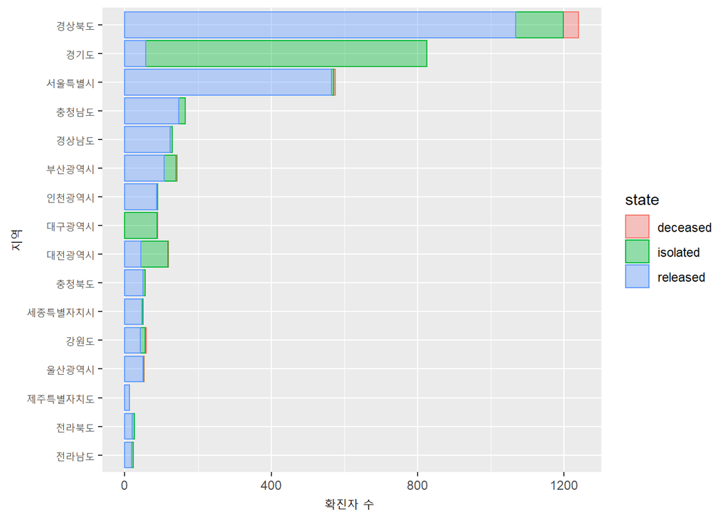

```r
data %>%
  group_by(province, state) %>%
  summarise(count = n()) %>%
  ggplot(aes(x= count, y = reorder(province, count))) +
  geom_bar(stat = "identity", aes(fill = state, colour = state), alpha=0.4) +
  labs(x="확진자 수 ", y="지역")
```

## Q3. Box plot

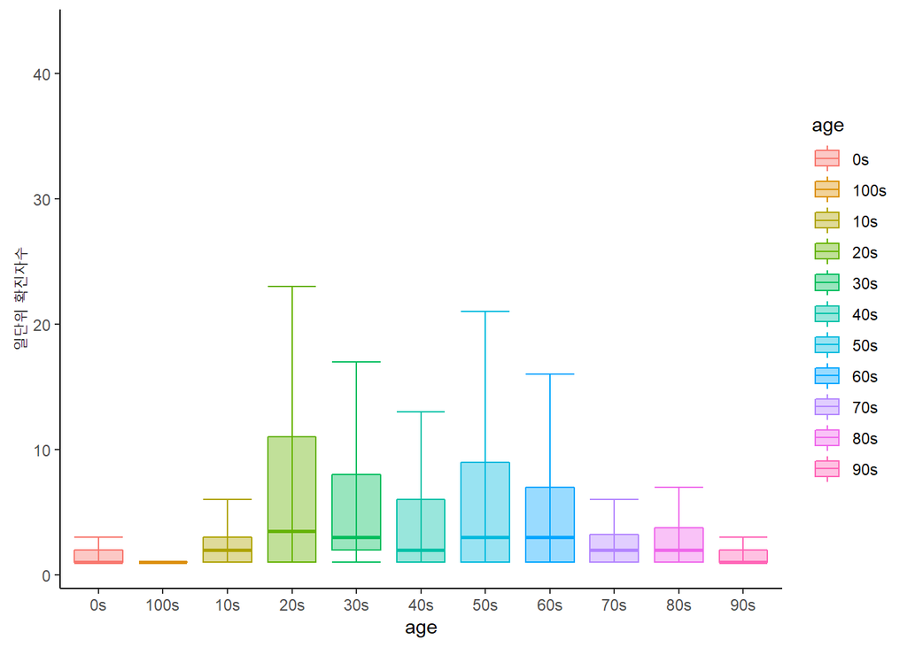

```r
data %>%
  group_by(age, confirmed_date) %>%
  summarise(
    count=n()
  ) %>%
  ggplot(aes(age, count)) +
  geom_boxplot(aes(x=age, y=count, fill=age, colour=age),
               alpha=0.4,
               outlier.shape = NA) +
  stat_boxplot(geom='errorbar', aes(color = age)) +
  theme_classic() +
  labs(y="일단위 확진자수")
```

## Q3-2. one-way ANOVA

```r
data %>%
  group_by(age, confirmed_date) %>%
  summarise(
    count=n()
  ) %>%
  aov(count ~ age, data=.) %>%
  summary
```

```
##              Df Sum Sq Mean Sq F value   Pr(>F)
## age          10   2575  257.48   8.823 8.19e-14 ***
## Residuals   780  22764   29.18
## ---
## Signif. codes:  0 '***' 0.001 '**' 0.01 '*' 0.05 '.' 0.1 ' ' 1
```

일원분산분석시 귀무가설(H0)는 ’나이대별 코로나19 확진자수 평균에 차이가 없다’로 생각하고 분산분석을 진행했습니다.  
결과에서 나이에 관한 P-value값이 매우 작아 귀무가설을 기각했으며, 나이대별 코로나 확진자수 평균에는 통계적으로 유의미한 차이가 있다는 해석을 했습니다.

## Q4. Map

1. 라이브러리 불러오기

```r
library(raster)
library(rgeos)
library(rgdal)
```

```r
library(maptools)
korea_map = readOGR("TL_SCCO_CTPRVN.shp"); korea_map
```

```
## class       : SpatialPolygonsDataFrame
## features    : 17
## extent      : 746110.3, 1387950, 1458754, 2068444  (xmin, xmax, ymin, ymax)
## crs         : +proj=tmerc +lat_0=38 +lon_0=127.5 +k=0.9996 +x_0=1000000 +y_0=2000000 +ellps=GRS80 +units=m +no_defs
## variables   : 3
## names       : CTPRVN_CD, CTP_ENG_NM, CTP_KOR_NM
## min values  :        11,      Busan,     강원도
## max values  :        50,      Ulsan,   충청북도
```

```r
korea_map@data
```

```
##    CTPRVN_CD        CTP_ENG_NM     CTP_KOR_NM
## 0         42        Gangwon-do         강원도
## 1         41       Gyeonggi-do         경기도
## 2         48  Gyeongsangnam-do       경상남도
## 3         47  Gyeongsangbuk-do       경상북도
## 4         29           Gwangju     광주광역시
## 5         27             Daegu     대구광역시
## 6         30           Daejeon     대전광역시
## 7         26             Busan     부산광역시
## 8         11             Seoul     서울특별시
## 9         36         Sejong-si 세종특별자치시
## 10        31             Ulsan     울산광역시
## 11        28           Incheon     인천광역시
## 12        46       Jellanam-do       전라남도
## 13        45      Jeollabuk-do       전라북도
## 14        50           Jeju-do 제주특별자치도
## 15        44 Chungcheongnam-do       충청남도
## 16        43 Chungcheongbuk-do       충청북도
```

```r
korea = fortify(korea_map, region='CTP_KOR_NM')
```

```
## SpP is invalid
```

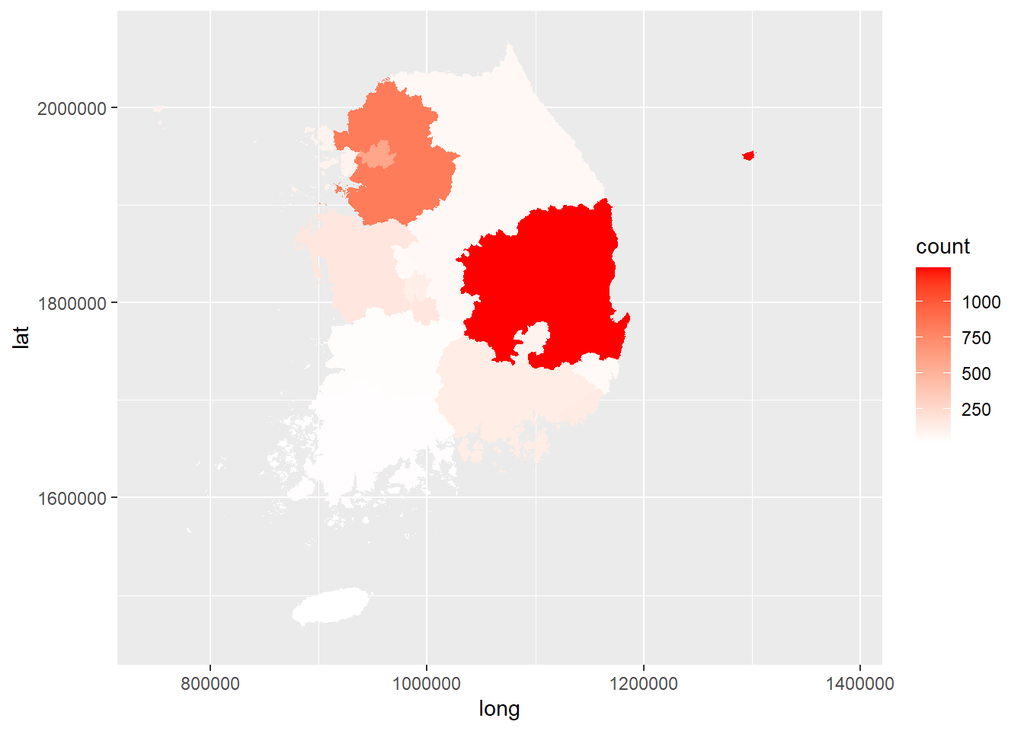

```r
data %>%
  group_by(province) %>%
  summarise(count=n()) %>%
  left_join(x=korea, y=., by=c("id"="province")) %>%
  ggplot(aes(long, lat)) +
  geom_polygon(aes(fill=count, group=group)) +
  scale_fill_gradient(low="white", high="red")
```